# **Unsupervised Learning Practice Project: Fantasy Sports Clustering Analysis**

## **Context**

Fantasy sports are online gaming platforms where participants draft and manage virtual teams of real professional sports players. Based on the performance of the players in the real world, players are allotted points in the fantasy sports platform every match. The objective is to create the best possible team with a fixed budget to score maximum fantasy points, and users compete against each other over an entire sports league or season. Some of these fantasy sports require actual financial investments for participation, with the chances of winning monetary rewards as well as free matchday tickets on a periodic basis.

The fantasy sports market has seen tremendous growth over the past few years, with a valuation of \$18.6 billion in 2019. The football (soccer) segment led in terms of market share in 2019, with over 8 million participants worldwide, and is expected to retain its dominance over the next couple of years. Digitalization is one of the primary factors driving the growth of the fantasy sports market as it allows participants the opportunity to compete on a global level and test their skills. With an increase in smartphone usage and availability of fantasy sports apps, this market is expected to witness a globe surge and reach a \\$48.6 billion valuation by 2027.

## **Objective**

OnSports is a fantasy sports platform that has fantasy leagues for many different sports and has witnessed an increasing number of participants globally over the past 5 years. For each player, a price is set at the start, and the price keeps changing over time based on the performance of the players in the real world. With the new English Premier League season about to start, they have collected data from the past season and want to analyze it to determine the price of each player for the start of the new season. OnSports have hired you as a data scientist and asked you to conduct a cluster analysis to identify players of different potentials of each player based on previous season performance. This will help them understand the patterns in player performances and fantasy returns and decide the exact price to be set for each player for the upcoming football season.

## **Data Description**

- **Player_Name:** Name of the player.
- **Club:** Club in which the player plays.
- **Position:** Position in which the player plays.
- **Goals_Scored:** Number of goals scored by the player in the previous season.
- **Assists:** Number of passes made by the player leading to goals in the previous season.
- **Total_Points:** Total number of fantasy points scored by the player in the previous season.
- **Minutes:** Number of minutes played by the player in the previous season.
- **Goals_Conceded:** Number of goals conceded by the player in the previous season.
- **Creativity:** A score, computed using a range of stats, that assesses player performance in terms of producing goalscoring opportunities for other players.
- **Influence:** A score, computed using a range of stats, that evaluates a player's impact on a match, taking into account actions that could directly or indirectly affect the match outcome.
- **Threat:** A score, computed using a range of stats, that gauges players who are most likely to score goals.
- **Bonus:** Total bonus points received. The three best performing players in each match receive additional bonus points based on a score computed using a range of stats. 3 points are awarded to the highest scoring player, 2 to the second best, and 1 to the third.
- **Clean_Sheets:** Number of matches without conceding a goal in the previous season.

## **Importing the necessary libraries and overview of the dataset**

```python
# Libraries to help with reading and manipulating data
import numpy as np
import pandas as pd

# Libraries to help with data visualization
import matplotlib.pyplot as plt
import seaborn as sns

sns.set_theme(style='darkgrid')

# Removes the limit for the number of displayed columns
pd.set_option("display.max_columns", None)

# Sets the limit for the number of displayed rows
pd.set_option("display.max_rows", 200)

# To scale the data using z-score
from sklearn.preprocessing import StandardScaler

# To compute distances
from scipy.spatial.distance import cdist, pdist

# To perform K-means clustering and compute silhouette scores
from sklearn.cluster import KMeans
from sklearn.metrics import silhouette_score

# To import K-Medoids
!pip install scikit-learn-extra
from sklearn_extra.cluster import KMedoids

# To import DBSCAN and Gaussian Mixture
from sklearn.cluster import DBSCAN
from sklearn.mixture import GaussianMixture

# To perform hierarchical clustering, compute cophenetic correlation, and create dendrograms
from sklearn.cluster import AgglomerativeClustering
from scipy.cluster.hierarchy import dendrogram, linkage, cophenet

# To suppress warnings
import warnings
warnings.filterwarnings("ignore")
```

```python
# Import data

data = pd.read_csv("fpl_data.csv")
```

```python
# Check the shape of the data

data.shape
```

```
(476, 13)
```

The data has 476 rows and 13 columns

```python
# Pull a sample of the data

data.sample(n = 10, random_state = 1)
```

|  | Player_Name | Club | Position | Goals_Scored | Assists | Total_Points | Minutes | Goals_Conceded | Creativity | Influence | Threat | Bonus | Clean_Sheets |
| --- | --- | --- | --- | --- | --- | --- | --- | --- | --- | --- | --- | --- | --- |
| 441 | Mark Noble | West Ham United | Midfielder | 0 | 0 | 27 | 701 | 15 | 88.6 | 80.4 | 7 | 0 | 0 |
| 363 | Sean Longstaff | Newcastle United | Midfielder | 0 | 1 | 41 | 1405 | 26 | 182.8 | 179.2 | 148 | 1 | 2 |
| 31 | Anwar El Ghazi | Aston Villa | Midfielder | 10 | 0 | 111 | 1604 | 22 | 426.1 | 500.4 | 726 | 13 | 5 |
| 132 | Olivier Giroud | Chelsea | Forward | 4 | 0 | 47 | 740 | 5 | 112.0 | 161.4 | 403 | 6 | 4 |
| 90 | Chris Wood | Burnley | Forward | 12 | 3 | 138 | 2741 | 43 | 323.2 | 595.8 | 1129 | 16 | 9 |
| 249 | Vontae Daley-Campbell | Leicester City | Defender | 0 | 0 | 0 | 0 | 0 | 0.0 | 0.0 | 0 | 0 | 0 |
| 65 | Danny Welbeck | Brighton and Hove Albion | Forward | 6 | 4 | 89 | 1541 | 18 | 269.7 | 319.8 | 595 | 15 | 6 |
| 445 | Ryan Fredericks | West Ham United | Defender | 1 | 1 | 28 | 564 | 9 | 166.8 | 155.2 | 96 | 0 | 1 |
| 117 | Christian Pulisic | Chelsea | Midfielder | 4 | 3 | 82 | 1731 | 21 | 378.8 | 361.4 | 724 | 3 | 7 |
| 415 | Ryan Sessegnon | Tottenham Hotspurs | Defender | 0 | 0 | 0 | 0 | 0 | 0.0 | 0.0 | 0 | 0 | 0 |

```python
# Copy the data to another variable to avoid any changes to original data

df = data.copy()
```

```python
# Check the column names and datatypes

df.info()
```

```
<class 'pandas.core.frame.DataFrame'>
RangeIndex: 476 entries, 0 to 475
Data columns (total 13 columns):
 #   Column          Non-Null Count  Dtype
---  ------          --------------  -----
 0   Player_Name     476 non-null    object
 1   Club            476 non-null    object
 2   Position        476 non-null    object
 3   Goals_Scored    476 non-null    int64
 4   Assists         476 non-null    int64
 5   Total_Points    476 non-null    int64
 6   Minutes         476 non-null    int64
 7   Goals_Conceded  476 non-null    int64
 8   Creativity      476 non-null    float64
 9   Influence       476 non-null    float64
 10  Threat          476 non-null    int64
 11  Bonus           476 non-null    int64
 12  Clean_Sheets    476 non-null    int64
dtypes: float64(2), int64(8), object(3)
memory usage: 48.5+ KB
```

- Categorical variables include: Player_Name, Club, and Position
- All other columns are numerical data type

```python
# Check for duplicate values

df.duplicated().sum()
```

```
0
```

- No duplicate values were found

```python
# Check for missing values in the data

df.isnull().sum()
```

```
Player_Name       0
Club              0
Position          0
Goals_Scored      0
Assists           0
Total_Points      0
Minutes           0
Goals_Conceded    0
Creativity        0
Influence         0
Threat            0
Bonus             0
Clean_Sheets      0
dtype: int64
```

- There are no missing values in the data

## **Exploratory Data Analysis**

**Let's check the statistical summary of the data**

```python
# Pull statistics for the data

df.describe(include = 'all').T
```

|  | count | unique | top | freq | mean | std | min | 25% | 50% | 75% | max |
| --- | --- | --- | --- | --- | --- | --- | --- | --- | --- | --- | --- |
| Player_Name | 476 | 476 | Alex Runnarsson | 1 | NaN | NaN | NaN | NaN | NaN | NaN | NaN |
| Club | 476 | 17 | Arsenal | 30 | NaN | NaN | NaN | NaN | NaN | NaN | NaN |
| Position | 476 | 4 | Midfielder | 195 | NaN | NaN | NaN | NaN | NaN | NaN | NaN |
| Goals_Scored | 476.0 | NaN | NaN | NaN | 1.907563 | 3.455562 | 0.0 | 0.0 | 0.5 | 2.0 | 23.0 |
| Assists | 476.0 | NaN | NaN | NaN | 1.752101 | 2.708563 | 0.0 | 0.0 | 0.0 | 2.0 | 14.0 |
| Total_Points | 476.0 | NaN | NaN | NaN | 58.516807 | 51.293559 | 0.0 | 10.0 | 48.0 | 94.25 | 244.0 |
| Minutes | 476.0 | NaN | NaN | NaN | 1336.909664 | 1073.773995 | 0.0 | 268.75 | 1269.5 | 2256.25 | 3420.0 |
| Goals_Conceded | 476.0 | NaN | NaN | NaN | 19.157563 | 15.946171 | 0.0 | 4.0 | 18.0 | 31.0 | 68.0 |
| Creativity | 476.0 | NaN | NaN | NaN | 195.97605 | 251.478541 | 0.0 | 8.3 | 96.95 | 296.95 | 1414.9 |
| Influence | 476.0 | NaN | NaN | NaN | 294.617647 | 267.779681 | 0.0 | 46.5 | 233.1 | 499.5 | 1318.2 |
| Threat | 476.0 | NaN | NaN | NaN | 224.962185 | 318.240377 | 0.0 | 5.75 | 104.5 | 298.25 | 1980.0 |
| Bonus | 476.0 | NaN | NaN | NaN | 4.718487 | 6.252625 | 0.0 | 0.0 | 2.0 | 7.0 | 40.0 |
| Clean_Sheets | 476.0 | NaN | NaN | NaN | 4.745798 | 4.394312 | 0.0 | 0.0 | 4.0 | 8.0 | 19.0 |

**Observations and Insights:**

- Most of the players play the Midfield position
- The players come from 17 different clubs
- 50% of players have no goals assists
- More than 50% of players have scored 1 or no goals
- The average play time is ~1350 minutes
- Players scored an average ~60 fantasy points in the previous season

### **Univariate Analysis**

```python
# Function to plot a boxplot and a histogram along the same scale


def histogram_boxplot(data, feature, figsize = (12, 7), kde = False, bins = None):

    """
    Boxplot and histogram combined

    data: dataframe
    feature: dataframe column
    figsize: size of figure (default (12, 7))
    kde: whether to the show density curve (default False)
    bins: number of bins for histogram (default None)
    """

    f2, (ax_box2, ax_hist2) = plt.subplots(
        nrows = 2,  # Number of rows of the subplot grid= 2
        sharex = True,  # X-axis will be shared among all subplots
        gridspec_kw = {"height_ratios": (0.25, 0.75)},
        figsize = figsize,
    )  # Creating the 2 subplots
    sns.boxplot(
        data = data, x = feature, ax = ax_box2, showmeans = True, color = "violet"
    )  # Boxplot will be created and a star will indicate the mean value of the column
    sns.histplot(
        data = data, x = feature, kde = kde, ax = ax_hist2, bins = bins, palette = "winter"
    ) if bins else sns.histplot(
        data = data, x = feature, kde = kde, ax = ax_hist2
    )  # For histogram
    ax_hist2.axvline(
        data[feature].mean(), color = "green", linestyle = "--"
    )  # Add mean to the histogram
    ax_hist2.axvline(
        data[feature].median(), color = "black", linestyle = "-"
    )  # Add median to the histogram
```

**`Goals_Scored`**

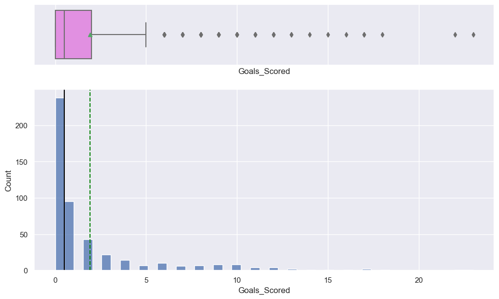

```python
# Create histogram plot for Goals_Scored

histogram_boxplot(df, 'Goals_Scored')
```

- The distribution is skewed to the right. Few players have scored more than 15 goals

**`Assists`**

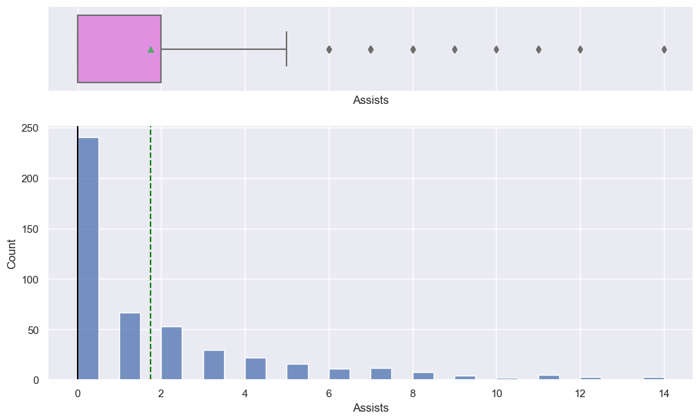

```python
# Create histogram plot for Assists

histogram_boxplot(df, 'Assists')
```

- Few players have assisted more than 8 goals
- The distribution is skewedc to the right

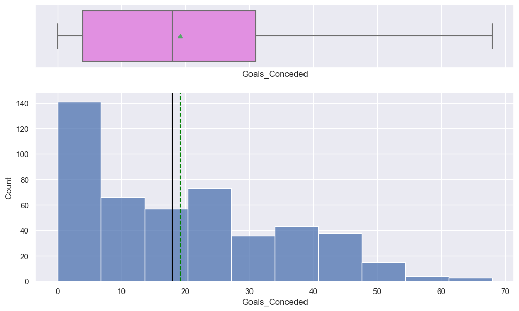

```python
# Plot the histogram and the boxplot for 'Goals_Conceded'

histogram_boxplot(df, 'Goals_Conceded')
```

- About 50% of players have conceded 20 or less goals
- The distribution is observed to be skewed slightly to the right

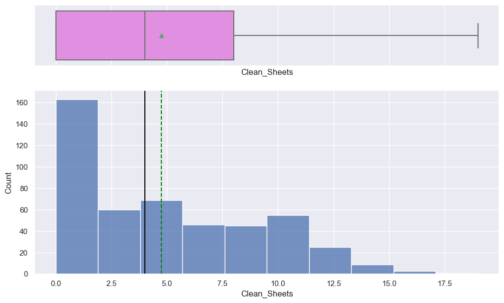

```python
# Plot the histogram and the boxplot for 'Clean_Sheets'

histogram_boxplot(df, 'Clean_Sheets')
```

- 50% of the players have kept 4 or less clean sheets
- The distribution is skewed slightly to the right

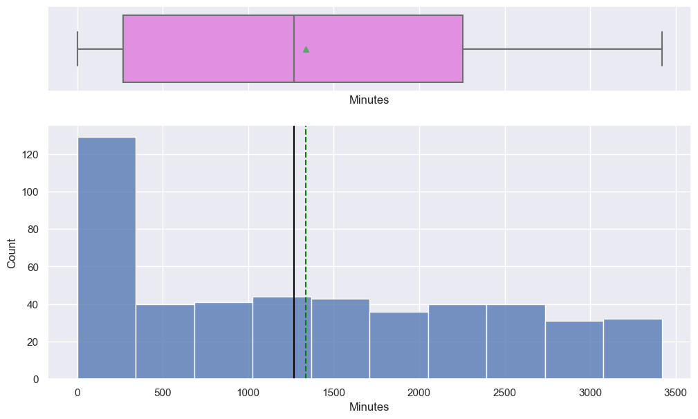

```python
# Plot the histogram and the boxplot for 'Minutes'

histogram_boxplot(df, 'Minutes')
```

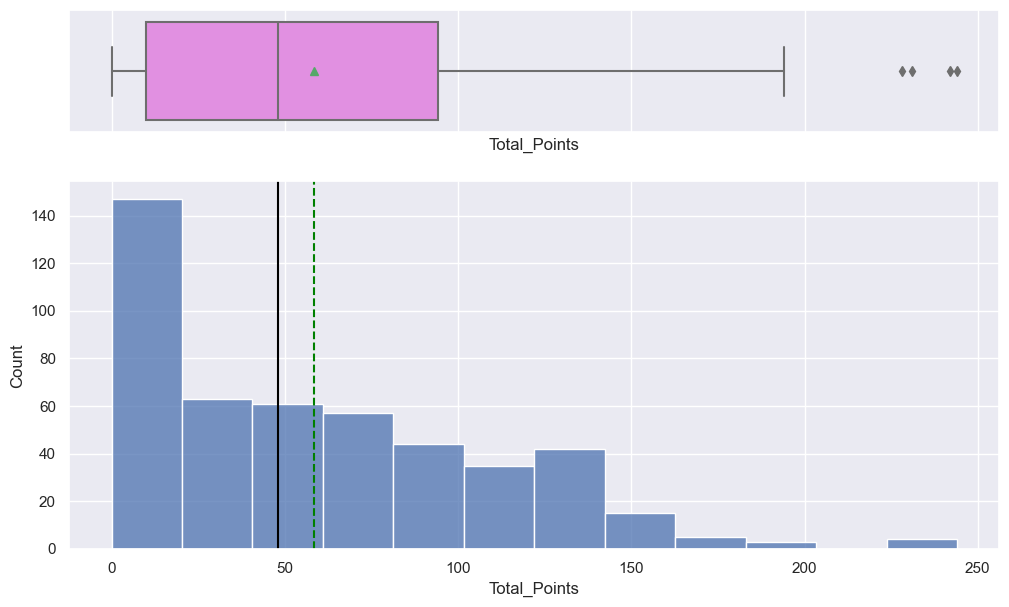

```python
# Plot the histogram and the boxplot for 'Total_Points'

histogram_boxplot(df, 'Total_Points')
```

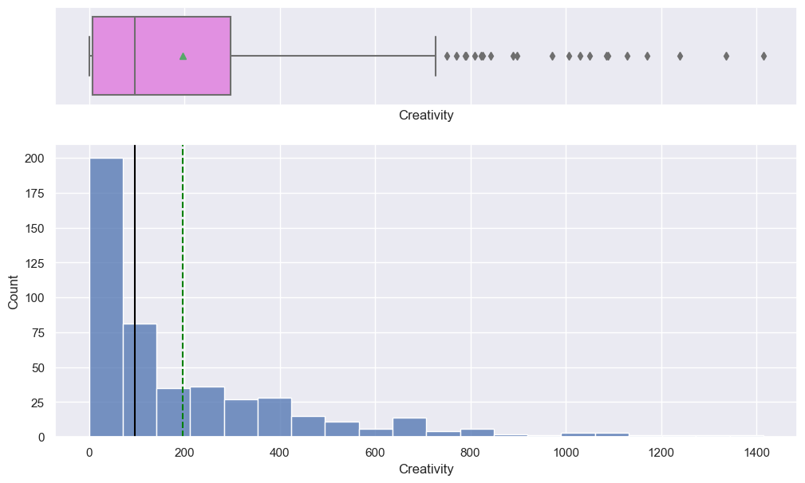

```python
# Plot the histogram and the boxplot for 'Creativity'

histogram_boxplot(df, 'Creativity')
```

- A right-skewed distribution is observed
- Few players have a creativity score of more than 500

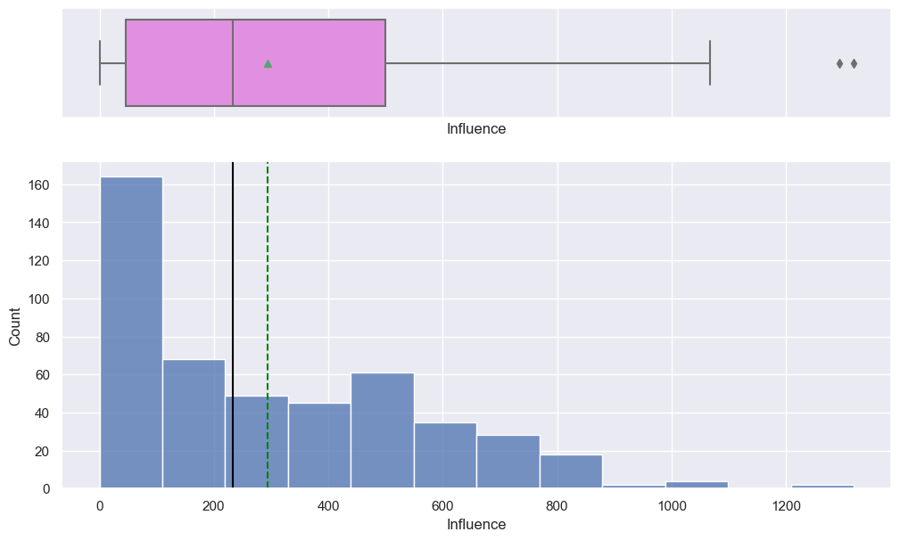

```python
# Plot the histogram and the boxplot for 'Influence'

histogram_boxplot(df, 'Influence')
```

- The distribution is right-skewed
- Few players have an influence score of over 800

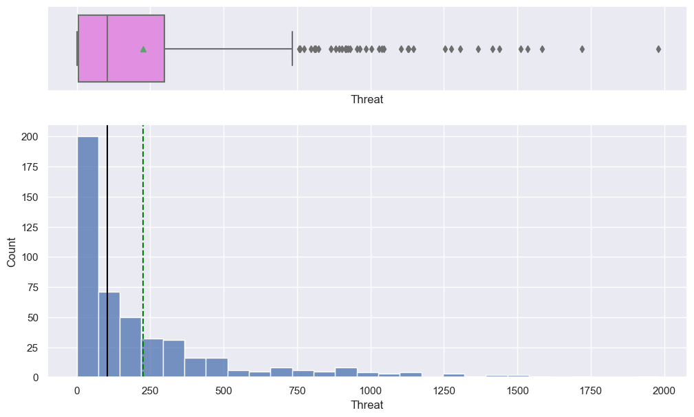

```python
# Plot the histogram and the boxplot for 'Threat'

histogram_boxplot(df, 'Threat')
```

- A right-skewed distribution is observed
- Few players have a threat score of over 500

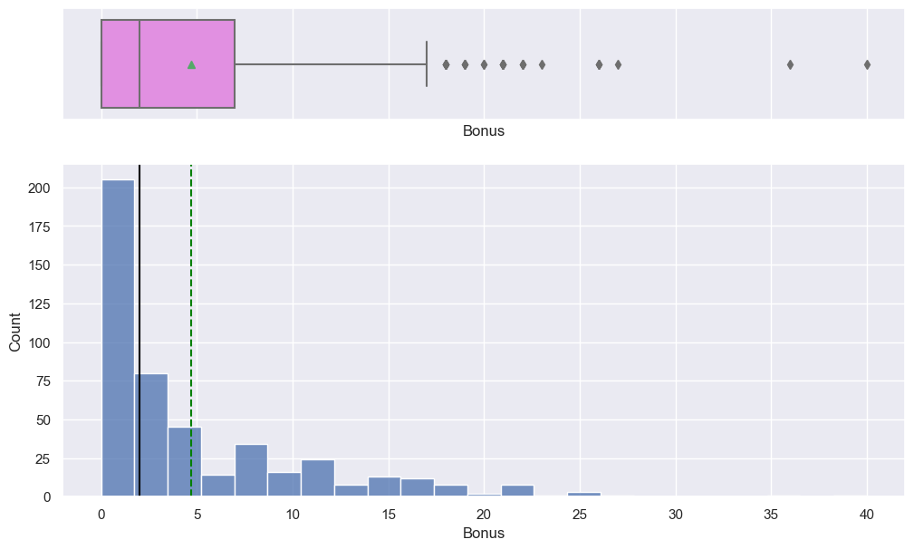

```python
# Plot the histogram and the boxplot for 'Bonus'

histogram_boxplot(df, 'Bonus')
```

- The distribution is right-skewed
- Few players received more than 20 bonus fantasy points in the last season

**Observations and Insights for all the plots:** A majority of the plots had a right-skewed distribution with a few players serving as outliers to variables such as Goals_Scored, Assists, Total_Points, Creativity, Influence, Threat, and Bonus

```python
# Function to create labeled barplots


def labeled_barplot(data, feature, perc = False, n = None):
    """
    Barplot with percentage at the top

    data: dataframe
    feature: dataframe column
    perc: whether to display percentages instead of count (default is False)
    n: displays the top n category levels (default is None, i.e., display all levels)
    """

    total = len(data[feature])  # Length of the column
    count = data[feature].nunique()
    if n is None:
        plt.figure(figsize = (count + 1, 5))
    else:
        plt.figure(figsize = (n + 1, 5))

    plt.xticks(rotation = 90, fontsize = 15)
    ax = sns.countplot(
        data = data,
        x = feature,
        palette = "Paired",
        order = data[feature].value_counts().index[:n].sort_values(),
    )

    for p in ax.patches:
        if perc == True:
            label = "{:.1f}%".format(
                100 * p.get_height() / total
            )  # Percentage of each class of the category
        else:
            label = p.get_height()  # Count of each level of the category

        x = p.get_x() + p.get_width() / 2  # Width of the plot
        y = p.get_height()  # Height of the plot

        ax.annotate(
            label,
            (x, y),
            ha = "center",
            va = "center",
            size = 12,
            xytext = (0, 5),
            textcoords = "offset points",
        )  # Annotate the percentage

    plt.show()  # Show the plot
```

**`Club`**

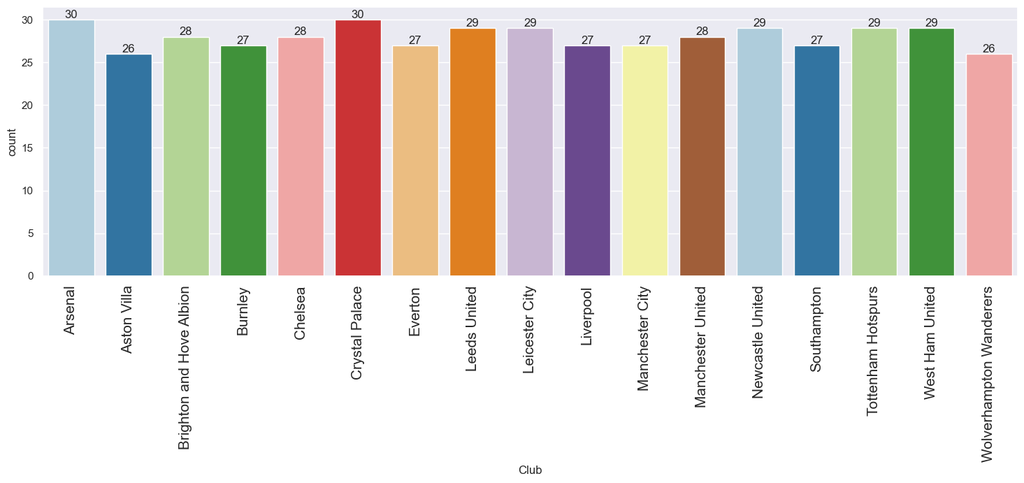

```python
labeled_barplot(df, 'Club')
```

- The minimum number of players in any club is 26
- The number of players in each club is almost uniformly distributed

**`Position`**

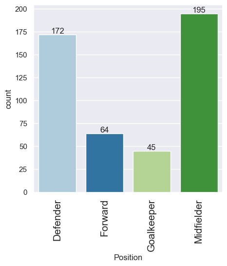

```python
# Create a labelled barplot for 'Position'

labeled_barplot(df,'Position')
```

**Observations and Insights:**

- There are 4x the number of Midfielders than Goal Keepers
  - This is understandable since there can only be one Goal Keeper on the field, per team
- There are 3x more Defenders than there are Forwards

### **Bivariate Analysis**

**We are done with univariate analysis. Let's explore the data a bit more with bivariate analysis.**

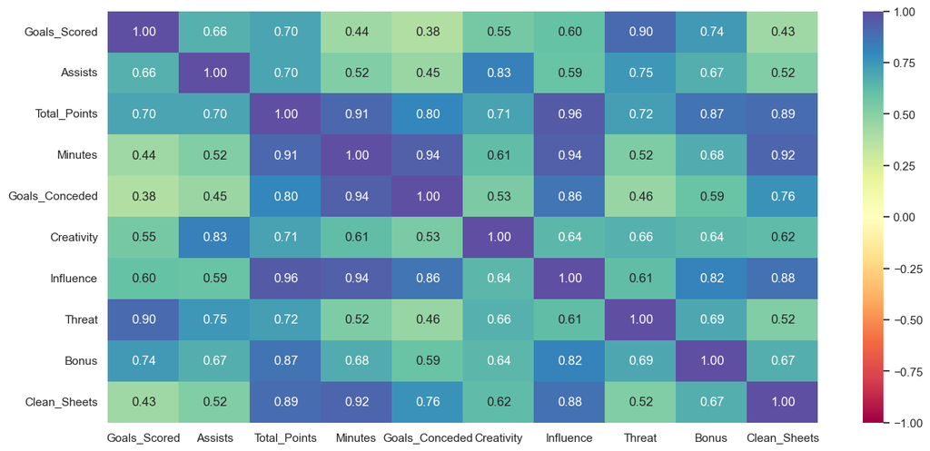

```python
# Correlation check
cols_list = df.select_dtypes(include = np.number).columns.tolist()

plt.figure(figsize = (15, 7))

sns.heatmap(
    df[cols_list].corr(), annot = True, vmin = -1, vmax = 1, fmt = ".2f", cmap = "Spectral"
)

plt.show()
```

**Observations and Insights:**

- The variables appear to be highly correlated to one another
- The number of goals and threat score of a player appear to be highly correlated
- Influence score is highly correlated with total fantasy points scored, as well as the number of minutes played by a player

**Let's check players from which team have scored the most fantasy points on average.**

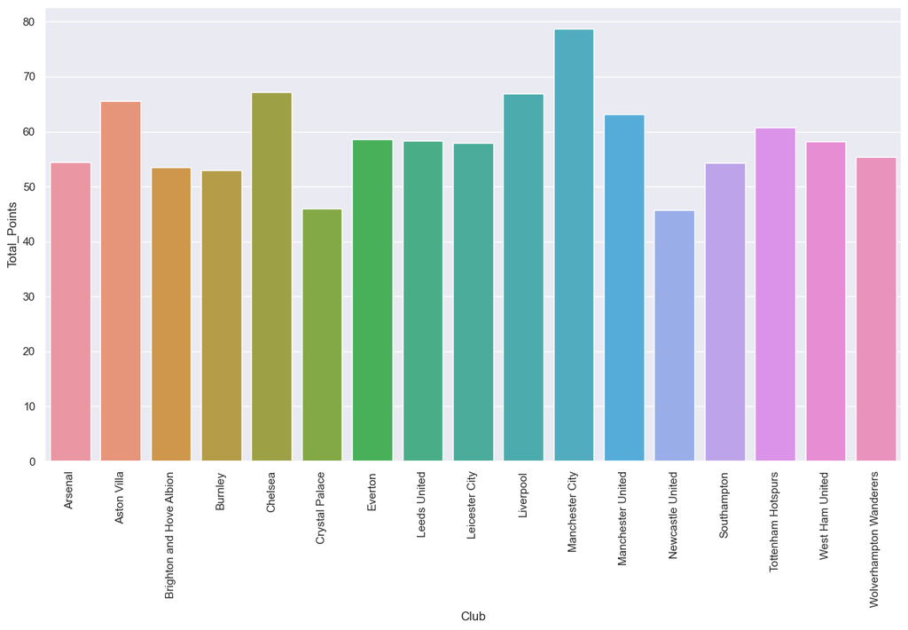

```python
plt.figure(figsize = (15, 8))

sns.barplot(data = df, x = 'Club', y = 'Total_Points' , ci = False)

plt.xticks(rotation = 90)

plt.show()
```

- The players from Manchester City appear to score more than average on fantasy points

**We know that players in different positions have specific roles to play in a team. Let's check players in which positions tend to score more fantasy points on average.**

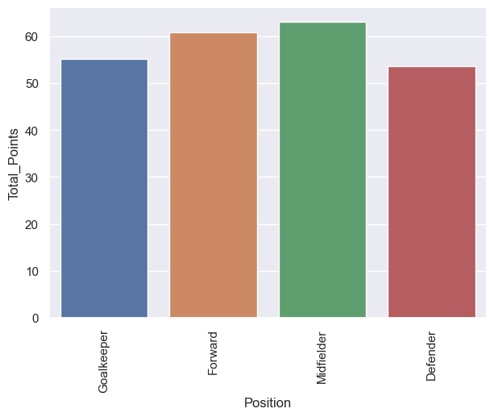

```python
# Check to see which players score more fantasy points on average

plt.figure(figsize = (7, 5))
sns.barplot(data = df, x = 'Position', y = 'Total_Points', ci = False)
plt.xticks(rotation = 90)
plt.show()
```

- Midfielders obtain the most number of points for fantasy managers

**To effectively utilize their squad depth, managers often rotate the squad to keep key players in shape for tougher games. Let's check the total number of minutes played, on average, across different positions.**

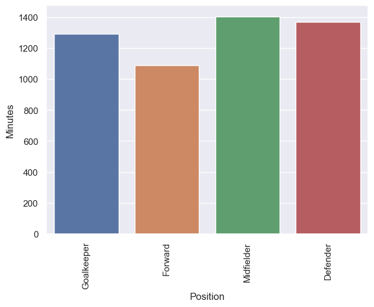

```python
# Check total number of minutes played across different positions

plt.figure(figsize = (7, 5))
sns.barplot(data = df, x = 'Position', y = 'Minutes', ci = False)
plt.xticks(rotation = 90)
plt.show()
```

- Midfielders and Defense players played more minutes on average compared to other positions

**Every point counts in fantasy sports and getting bonus points for a player is always a treat. Let's check which team's players have secured the most bonus points, on average, last season.**

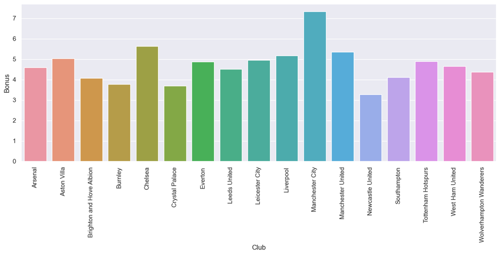

```python
# Check team's players that have the most bonus points from last season

plt.figure(figsize = (15, 5))
sns.barplot(data = df, x = 'Club', y = 'Bonus', ci = False)
plt.xticks(rotation = 90)
plt.show()
```

- Manchester City players have the most bonus points from last season

**Let's see which players scored the most fantasy points last season for different positions of play.**

```python
pos_list = df.Position.unique().tolist()
best_df = pd.DataFrame()

for pos in pos_list:
    df_aux = df[df.Position == pos]
    best_df = best_df.append(df_aux[df_aux.Total_Points == df_aux.Total_Points.max()][['Player_Name', 'Club', 'Position', 'Total_Points']])

best_df
```

|  | Player_Name | Club | Position | Total_Points |
| --- | --- | --- | --- | --- |
| 36 | Emiliano Martinez | Aston Villa | Goalkeeper | 186 |
| 403 | Harry Kane | Tottenham Hotspurs | Forward | 242 |
| 315 | Bruno Fernandes | Manchester United | Midfielder | 244 |
| 223 | Stuart Dallas | Leeds United | Defender | 171 |

- The above players scored the most fantasy points for last season, with Bruno Fernandes and Harry Kane being in the top 2

**Let's see the top 10 players with the most fantasy points last season for different positions of play.**

```python
best10_df = pd.DataFrame()

for pos in pos_list:
    df_aux = df[df.Position == pos]
    best10_df = best10_df.append(df_aux.sort_values('Total_Points', ascending = False).reset_index(drop = True).loc[:10, ['Player_Name', 'Club', 'Position', 'Total_Points']])

best10_df
```

|  | Player_Name | Club | Position | Total_Points |
| --- | --- | --- | --- | --- |
| 0 | Emiliano Martinez | Aston Villa | Goalkeeper | 186 |
| 1 | Ederson Moares | Manchester City | Goalkeeper | 160 |
| 2 | Illan Meslier | Leeds United | Goalkeeper | 154 |
| 3 | Hugo Lloris | Tottenham Hotspurs | Goalkeeper | 149 |
| 4 | Nick Pope | Burnley | Goalkeeper | 144 |
| 5 | Alisson Becker | Liverpool | Goalkeeper | 140 |
| 6 | Edouard Mendy | Chelsea | Goalkeeper | 140 |
| 7 | Lukasz Fabianski | West Ham United | Goalkeeper | 133 |
| 8 | Rui Pedro Patricio | Wolverhampton Wanderers | Goalkeeper | 132 |
| 9 | Bernd Leno | Arsenal | Goalkeeper | 131 |
| 10 | Kasper Schmeichel | Leicester City | Goalkeeper | 128 |
| 0 | Harry Kane | Tottenham Hotspurs | Forward | 242 |
| 1 | Patrick Bamford | Leeds United | Forward | 194 |
| 2 | Jamie Vardy | Leicester City | Forward | 187 |
| 3 | Ollie Watkins | Aston Villa | Forward | 168 |
| 4 | Dominic Calvert-Lewin | Everton | Forward | 165 |
| 5 | Roberto Firmino | Liverpool | Forward | 141 |
| 6 | Chris Wood | Burnley | Forward | 138 |
| 7 | Che Adams | Southampton | Forward | 137 |
| 8 | Callum Wilson | Newcastle United | Forward | 134 |
| 9 | Danny Ings | Southampton | Forward | 131 |
| 10 | Alexandre Lacazette | Arsenal | Forward | 129 |
| 0 | Bruno Fernandes | Manchester United | Midfielder | 244 |
| 1 | Mohamed Salah | Liverpool | Midfielder | 231 |
| 2 | Heung-Min Son | Tottenham Hotspurs | Midfielder | 228 |
| 3 | Sadio Mane | Liverpool | Midfielder | 176 |
| 4 | Marcus Rashford | Manchester United | Midfielder | 174 |
| 5 | Jack Harrison | Leeds United | Midfielder | 160 |
| 6 | Ilkay Gundogan | Manchester City | Midfielder | 157 |
| 7 | James Ward-Prowse | Southampton | Midfielder | 156 |
| 8 | Raheem Sterling | Manchester City | Midfielder | 154 |
| 9 | Tomas Soucek | West Ham United | Midfielder | 147 |
| 10 | Mason Mount | Chelsea | Midfielder | 147 |
| 0 | Stuart Dallas | Leeds United | Defender | 171 |
| 1 | Andrew Robertson | Liverpool | Defender | 161 |
| 2 | Trent Alexander-Arnold | Liverpool | Defender | 160 |
| 3 | Aaron Cresswell | West Ham United | Defender | 153 |
| 4 | Aaron Wan-Bissaka | Manchester United | Defender | 144 |
| 5 | Ruben Dias | Manchester City | Defender | 142 |
| 6 | Benjamin Chilwell | Chelsea | Defender | 139 |
| 7 | Matt Targett | Aston Villa | Defender | 138 |
| 8 | Joao Cancelo | Manchester City | Defender | 138 |
| 9 | Lewis Dunk | Brighton and Hove Albion | Defender | 130 |
| 10 | John Stones | Manchester City | Defender | 128 |

### **Outlier Check**

- Let's plot the boxplots of all numerical columns to check for outliers.

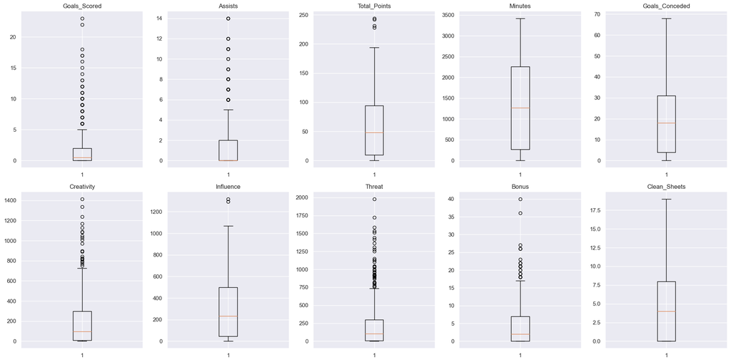

```python
plt.figure(figsize = (20, 10))

numeric_columns = df.select_dtypes(include = np.number).columns.tolist()

for i, variable in enumerate(numeric_columns):

    plt.subplot(2, 5, i + 1)

    plt.boxplot(df[variable], whis = 1.5)

    plt.tight_layout()

    plt.title(variable)

plt.show()
```

- There were some outliers observed, which will not be considered as proper values

### **Scaling**

- Let's scale the data before we proceed with clustering.

```python
# Scaling the data before clustering

scaler = StandardScaler() # Initialize the Standard Scaler

subset = df.iloc[:, 3:].copy()  # Get the data with numerical features

subset_scaled = scaler.fit_transform(subset) # Fit_transform the scaler function on data subset
```

```python
# Create a dataframe of the scaled data

subset_scaled_df = pd.DataFrame(subset_scaled, columns = subset.columns)
```

### **Applying PCA**

```python
# Import PCA

from sklearn.decomposition import PCA

# Define the number of principal components to generate

n = subset.shape[1]     # Storing the number of variables in the subset data

pca = PCA(n_components = n, random_state = 1)   # Initialize PCA with n_components = n and random_state = 1

data_pca = pd.DataFrame(pca.fit_transform(subset_scaled_df ))    # Fit_transform PCA on the scaled data

# The percentage of variance explained by each principal component is stored

exp_var = (pca.explained_variance_ratio_  )
```

## **K-Means Clustering**

```python
k_means_df = data_pca.copy()
```

```
Number of Clusters: 1 	Average Distortion: 2.773037110097803
Number of Clusters: 2 	Average Distortion: 1.8635736785898278
Number of Clusters: 3 	Average Distortion: 1.561277403810161
Number of Clusters: 4 	Average Distortion: 1.3542782238901427
Number of Clusters: 5 	Average Distortion: 1.29315416997417
Number of Clusters: 6 	Average Distortion: 1.225849543585495
Number of Clusters: 7 	Average Distortion: 1.1604840142134505
Number of Clusters: 8 	Average Distortion: 1.1098047584574389
Number of Clusters: 9 	Average Distortion: 1.0797310475776059
Number of Clusters: 10 	Average Distortion: 1.0174369926410636
Number of Clusters: 11 	Average Distortion: 1.0208747020267828
Number of Clusters: 12 	Average Distortion: 0.9850734409030889
Number of Clusters: 13 	Average Distortion: 0.9602766985773121
Number of Clusters: 14 	Average Distortion: 0.9413187781558088
```

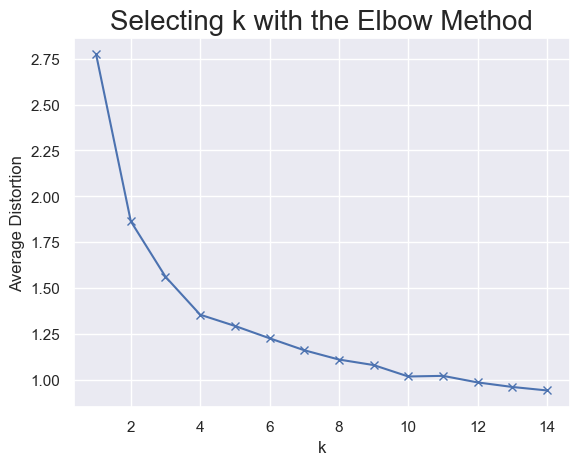

```python
clusters = range(1, 15)
meanDistortions = []

for k in clusters:

    model = KMeans(n_clusters = k, random_state = 1)

    model.fit(data_pca)

    prediction = model.predict(k_means_df)

    distortion = (
        sum(np.min(cdist(k_means_df, model.cluster_centers_, "euclidean"), axis = 1))
        / k_means_df.shape[0]
    )

    meanDistortions.append(distortion)

    print("Number of Clusters:", k, "\tAverage Distortion:", distortion)

plt.plot(clusters, meanDistortions, "bx-")

plt.xlabel("k")

plt.ylabel("Average Distortion")

plt.title("Selecting k with the Elbow Method", fontsize = 20)

plt.show()
```

**Observations and Insights:**

```python
# Create K-Means with nclusters = 4

kmeans = KMeans(n_clusters = 4, random_state = 1)
kmeans.fit(k_means_df)
```

```
KMeans(n_clusters=4, random_state=1)
```

```python
# Create a copy of the original data
df1 = df.copy()

# Adding K-Means cluster labels to the K-Means dataframe
k_means_df["KM_segments"] = kmeans.labels_

# Add K-Means cluster labels to the original dataframe
df1["KM_segments"] = kmeans.labels_
```

### **Cluster Profiling**

```python
# Group by the cluster labels

km_cluster_profile = df1.groupby("KM_segments").mean()
```

```python
# Create the "count_in_each_segment" feature in K-Means cluster profile

km_cluster_profile["count_in_each_segment"] = (
    df1.groupby("KM_segments")["Total_Points"].count().values)
```

```python
# Highlight the maximum average value among all the clusters for each of the variables
km_cluster_profile.style.highlight_max(color = "lightgreen", axis = 0)
```

| KM_segments | Goals_Scored | Assists | Total_Points | Minutes | Goals_Conceded | Creativity | Influence | Threat | Bonus | Clean_Sheets | count_in_each_segment |
| --- | --- | --- | --- | --- | --- | --- | --- | --- | --- | --- | --- |
| 0 | 1.460938 | 1.601562 | 55.648438 | 1389.453125 | 20.554688 | 187.653125 | 270.037500 | 218.117188 | 3.312500 | 4.687500 | 128 |
| 1 | 1.363636 | 1.878788 | 103.525253 | 2670.555556 | 37.525253 | 265.671717 | 579.185859 | 199.636364 | 7.676768 | 10.020202 | 99 |
| 2 | 9.147541 | 6.639344 | 141.557377 | 2446.704918 | 33.344262 | 617.495082 | 659.324590 | 880.540984 | 16.147541 | 9.213115 | 61 |
| 3 | 0.148936 | 0.202128 | 9.824468 | 238.750000 | 3.930851 | 28.171809 | 43.164894 | 30.244681 | 0.409574 | 0.558511 | 188 |

```python
# Print the players in each cluster. Hint: Use the KM_segments feature

for cl in df1["KM_segments"].unique():
    print("In cluster {}, the following players are present:".format(cl))
    print(df1[df1["KM_segments"] == cl]["Player_Name"].unique())
    print()
```

```
In cluster 3, the following players are present:
['Alex Runnarsson' 'Cedric Soares' 'Edward Nketiah'
 'Gabriel Teodoro Martinelli Silva' 'Matt Macey' 'Miguel Azeez'
 'Pablo Mari' 'Reiss Nelson' 'Sead Kolasinac' 'Shkodran Mustafi'
 'Sokratis Papastathopoulos' 'William Saliba' 'Ahmed El Mohamady'
 'Carney Chukwuemeka' 'Conor Hourihane' 'Henri Lansbury' 'Jacob Ramsey'
 'Jaden Philogene-Bidace' 'Jose Peleteiro Romallo' 'Keinan Davis'
 'Kortney Hause' 'Marvelous Nakamba' 'Morgan Sanson' 'Orjan Nyland'
 'Wesley Moraes' 'Alireza Jahanbakhsh' 'Andi Zeqiri'
 'Bernardo Fernandes da Silva Junior' 'Davy Propper' 'Jakub Moder'
 'Jason Steele' 'Jayson Molumby' 'Jose Izquierdo' 'Percy Tau'
 'Reda Khadra' 'Anthony Driscoll-Glennon' 'Bailey Peacock-Farrell'
 'Dale Stephens' 'Jimmy Dunne' 'Joel Mumbongo' 'Josh Benson' 'Kevin Long'
 'Lewis Richardson' 'Phil Bardsley' 'Will Norris' 'Billy Gilmour'
 'Emerson Palmieri dos Santos' 'Faustino Anjorin' 'Fikayo Tomori'
 'Karlo Ziger' 'Kepa Arrizabalaga' 'Valentino Livramento'
 'Willy Caballero' 'Connor Wickham' 'Jack Butland' 'James McCarthy'
 'James Tomkins' 'Jean-Philippe Mateta' 'Mamadou Sakho' 'Martin Kelly'
 'Nathan Ferguson' 'Reece Hannam' 'Ryan Inniss' 'Sam Woods'
 'Stephen Henderson' 'Anthony Gordon' 'Bernard Caldeira Duarte'
 'Cenk Tosun' 'Fabian Delph' 'Joao Virginia' 'Jonjoe Kenny' 'Joshua King'
 'Moise Kean' 'Nathan Broadhead' 'Niels Nkounkou' 'Robin Olsen'
 'Adam Forshaw' 'Francisco Casilla' 'Gaetano Berardi'
 'Ian Carlo Poveda-Ocampo' 'Jack Jenkins' 'Jamie Shackleton'
 'Jay-Roy Grot' 'Jordan Stevens' 'Kamil Miazek' 'Leif Davis'
 'Mateusz Bogusz' 'Niall Huggins' 'Pablo Hernandez' 'Cengiz Under'
 'Christian Fuchs' 'Daniel Amartey' 'Demarai Gray' 'Filip Benkovic'
 'Hamza Choudhury' 'Islam Slimani' 'Luke Thomas' 'Sidnei Tavares'
 'Thakgalo Leshabela' 'Vontae Daley-Campbell' 'Wes Morgan'
 'Adrian Castillo' 'Alex Oxlade-Chamberlain' 'Caoimhin Kelleher'
 'Divock Origi' 'Joel Matip' 'Joseph Gomez' 'Naby Keita' 'Neco Williams'
 'Ozan Kabak' 'Rhys Williams' 'Virgil van Dijk' 'Xherdan Shaqiri'
 'Eric Garcia' 'Liam Delap' 'Luke Mbete' 'Nathan Ake' 'Nicolas Otamendi'
 'Scott Carson' 'Taylor Harwood-Bellis' 'Zack Steffen'
 'Alex Nicolao Telles' 'Amad Diallo' 'Anthony Elanga' 'Axel Tuanzebe'
 'Brandon Williams' 'Donny van de Beek' 'Hannibal Mejbri' 'Juan Mata'
 'Nathan Bishop' 'Odion Ighalo' 'Shola Shoretire' 'William Fish'
 'Andy Carroll' 'DeAndre Yedlin' 'Dwight Gayle' 'Elliot Anderson'
 'Florian Lejeune' 'Javier Manquillo' 'Kelland Watts' 'Matthew Longstaff'
 'Yoshinori Muto' 'Caleb Watts' "Daniel N'Lundulu" 'Fraser Forster'
```

[output cut: 80 more lines]

```
 'Thiago Alcantara' 'Aymeric Laporte' 'Benjamin Mendy'
 'Fernando Luiz Rosa' 'Ferran Torres' 'Kyle Walker' 'Oleksandr Zinchenko'
 'Sergio Aguero' 'Anthony Martial' 'Daniel James' 'Eric Bailly'
 'Nemanja Matic' 'Allan Saint-Maximin' 'Ciaran Clark' 'Emil Krafth'
 'Fabian Schar' 'Federico Fernandez' 'Isaac Hayden' 'Jacob Murphy'
 'Jamaal Lascelles' 'Jamal Lewis' 'Joelinton de Lira' 'Joseph Willock'
 'Martin Dubravka' 'Matt Ritchie' 'Paul Dummett' 'Ryan Fraser'
 'Sean Longstaff' 'Ibrahima Diallo' 'Jack Stephens' 'Moussa Djenepo'
 'Nathan Redmond' 'Oriol Romeu Vidal' 'Takumi Minamino' 'Theo Walcott'
 'Ben Davies' 'Davinson Sanchez' 'Giovani Lo Celso' 'Lucas Moura'
 'Matt Doherty' 'Moussa Sissoko' 'Serge Aurier' 'Steven Bergwijn'
 'Arthur Masuaku' 'Craig Dawson' 'Fabian Balbuena' 'Issa Diop'
 'Said Benrahma' 'Sebastian Haller' 'Daniel Castelo Podence' 'Fabio Silva'
 'Max Kilman' 'Raul Jimenez ' 'Rayan Ait Nouri' 'Willian Jose'
 'Willy Boly']
```

```python
df1.groupby(["KM_segments", "Position"])['Player_Name'].count()
```

```
KM_segments  Position
0            Defender      47
             Forward       16
             Goalkeeper     3
             Midfielder    62
1            Defender      50
             Goalkeeper    17
             Midfielder    32
2            Defender       5
             Forward       20
             Midfielder    36
3            Defender      70
             Forward       28
             Goalkeeper    25
             Midfielder    65
Name: Player_Name, dtype: int64
```

- Cluster 1 has no forwards
- Cluster 2 has no goal keepers

**Let's plot the boxplot**

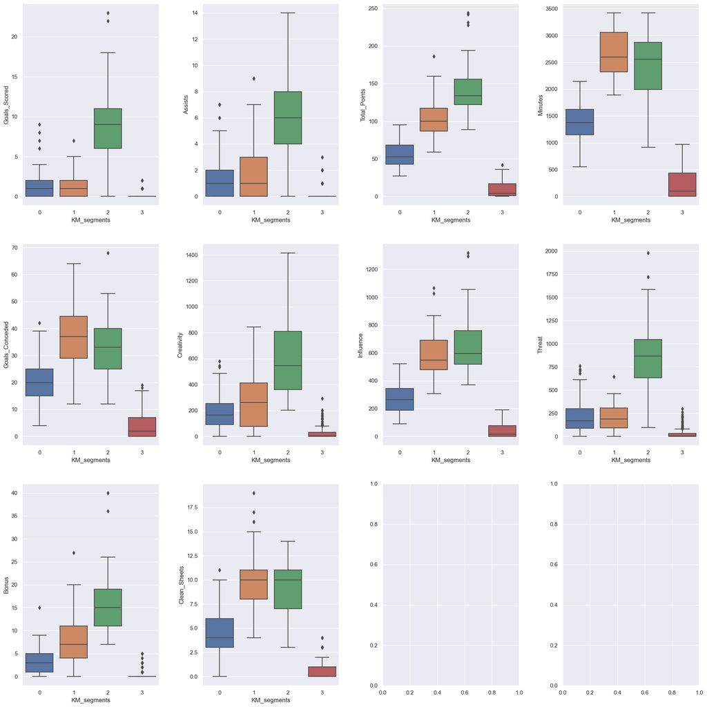

```python
fig, axes = plt.subplots(3, 4, figsize = (20, 20))
counter = 0

for ii in range(3):
    for jj in range(4):
        if counter < 10:
            sns.boxplot(
                ax = axes[ii][jj],
                data = df1,
                y = df1.columns[3 + counter],
                x = "KM_segments",
            )
            counter = counter + 1

fig.tight_layout(pad = 3.0)
```